# ArviZ.jl Quickstart

Note

This tutorial is adapted from [ArviZ's quickstart](https://arviz-devs.github.io/arviz/notebooks/Introduction.html).

```julia
using ArviZ
using PyPlot

# ArviZ ships with style sheets!
ArviZ.use_style("arviz-darkgrid")
```

## Get started with plotting

ArviZ.jl is designed to be used with libraries like [CmdStan](https://github.com/StanJulia/CmdStan.jl), [Turing.jl](https://turing.ml), and Soss.jl but works fine with raw arrays.

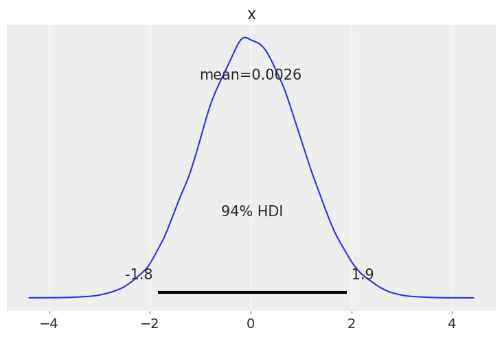

```julia
using Random

rng = Random.MersenneTwister(37772)
plot_posterior(randn(rng, 100_000));
gcf()
```

Plotting a dictionary of arrays, ArviZ.jl will interpret each key as the name of a different random variable. Each row of an array is treated as an independent series of draws from the variable, called a *chain*. Below, we have 10 chains of 50 draws each for four different distributions.

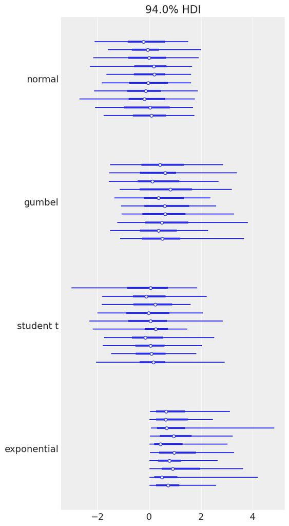

```julia
using Distributions

s = (10, 50)
plot_forest(Dict(
    "normal" => randn(rng, s),
    "gumbel" => rand(rng, Gumbel(), s),
    "student t" => rand(rng, TDist(6), s),
    "exponential" => rand(rng, Exponential(), s)
));
gcf()
```

## Plotting with MCMCChains.jl's `Chains` objects produced by Turing.jl

ArviZ is designed to work well with high dimensional, labelled data. Consider the [eight schools model](https://statmodeling.stat.columbia.edu/2014/01/21/everything-need-know-bayesian-statistics-learned-eight-schools/), which roughly tries to measure the effectiveness of SAT classes at eight different schools. To show off ArviZ's labelling, I give the schools the names of [a different eight schools](https://en.wikipedia.org/wiki/Eight_Schools_Association).

This model is small enough to write down, is hierarchical, and uses labelling. Additionally, a centered parameterization causes [divergences](https://mc-stan.org/users/documentation/case-studies/divergences_and_bias.html) (which are interesting for illustration).

First we create our data and set some sampling parameters.

```julia
J = 8
y = [28.0, 8.0, -3.0, 7.0, -1.0, 1.0, 18.0, 12.0]
σ = [15.0, 10.0, 16.0, 11.0, 9.0, 11.0, 10.0, 18.0]
schools = [
    "Choate",
    "Deerfield",
    "Phillips Andover",
    "Phillips Exeter",
    "Hotchkiss",
    "Lawrenceville",
    "St. Paul's",
    "Mt. Hermon"
];

nwarmup, nsamples, nchains = 1000, 1000, 4;
```

Now we write and run the model using Turing:

```julia
using Turing

Turing.@model turing_model(
    J,
    y,
    σ,
    ::Type{TV} = Vector{Float64},
) where {TV} = begin
    μ ~ Normal(0, 5)
    τ ~ truncated(Cauchy(0, 5), 0, Inf)
    θ = TV(undef, J)
    θ .~ Normal(μ, τ)
    y ~ MvNormal(θ, σ)
end

param_mod = turing_model(J, y, σ)
sampler = NUTS(nwarmup, 0.8)

rng = Random.MersenneTwister(16653)
turing_chns = sample(
    rng,
    param_mod,
    sampler,
    MCMCThreads(),
    nwarmup + nsamples,
    nchains;
    progress = false,
);
```

```
┌ Info: Found initial step size
└   ϵ = 1.6
```

Most ArviZ functions work fine with `Chains` objects from Turing:

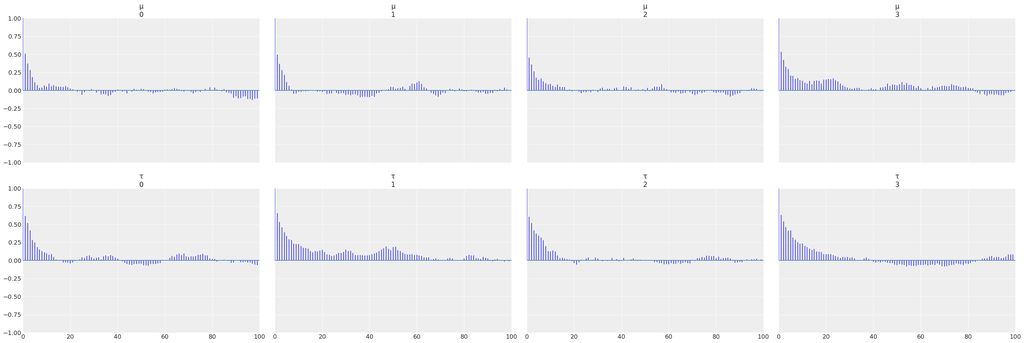

```julia
plot_autocorr(turing_chns; var_names = ["μ", "τ"]);
gcf()
```

### Convert to `InferenceData`

For much more powerful querying, analysis and plotting, we can use built-in ArviZ utilities to convert `Chains` objects to xarray datasets. Note we are also giving some information about labelling.

ArviZ is built to work with `InferenceData` (a netcdf datastore that loads data into `xarray` datasets), and the more *groups* it has access to, the more powerful analyses it can perform.

```julia
idata = from_mcmcchains(
    turing_chns,
    coords = Dict("school" => schools),
    dims = Dict(
        "y" => ["school"],
        "σ" => ["school"],
        "θ" => ["school"],
    ),
    library = "Turing",
)
```

InferenceData

- posterior

  ```
  Dataset (xarray.Dataset)
  Dimensions:  (chain: 4, draw: 1000, school: 8)
  Coordinates:
    * chain    (chain) int64 0 1 2 3
    * draw     (draw) int64 0 1 2 3 4 5 6 7 8 ... 992 993 994 995 996 997 998 999
    * school   (school) <U16 'Choate' 'Deerfield' ... "St. Paul's" 'Mt. Hermon'
  Data variables:
      μ        (chain, draw) float64 7.718 8.108 7.318 3.507 ... 5.713 4.41 10.67
      τ        (chain, draw) float64 0.9271 0.8692 1.095 ... 4.172 2.761 2.359
      θ        (chain, draw, school) float64 8.637 6.667 7.506 ... 11.84 11.46
  Attributes:
      created_at:         2020-10-03T08:59:31.824468
      arviz_version:      0.10.0
      inference_library:  Turing
  ```

- sample_stats

  ```
  Dataset (xarray.Dataset)
  Dimensions:           (chain: 4, draw: 1000)
  Coordinates:
    * chain             (chain) int64 0 1 2 3
    * draw              (draw) int64 0 1 2 3 4 5 6 ... 993 994 995 996 997 998 999
  Data variables:
      energy            (chain, draw) float64 51.72 47.88 50.7 ... 59.78 59.25
      energy_error      (chain, draw) float64 0.0 1.653 1.054 ... -0.1556 -0.6509
      depth             (chain, draw) int64 3 2 2 5 3 3 5 4 5 ... 4 4 3 3 4 4 3 3
      diverging         (chain, draw) bool False False False ... False False False
      log_density       (chain, draw) float64 -43.78 -45.22 ... -52.96 -54.35
      max_energy_error  (chain, draw) float64 7.651 64.98 322.7 ... -1.106 0.815
      nom_step_size     (chain, draw) float64 0.1553 0.1553 ... 0.2897 0.2897
      is_accept         (chain, draw) float64 1.0 1.0 1.0 1.0 ... 1.0 1.0 1.0 1.0
      tree_size         (chain, draw) int64 15 7 7 31 7 7 31 ... 15 7 31 15 7 15
      lp                (chain, draw) float64 -43.78 -45.22 ... -52.96 -54.35
      step_size         (chain, draw) float64 0.1553 0.1553 ... 0.2897 0.2897
      mean_tree_accept  (chain, draw) float64 0.05272 0.07894 ... 0.9873 0.8885
  Attributes:
      created_at:         2020-10-03T08:59:31.854517
      arviz_version:      0.10.0
      inference_library:  Turing
  ```

Each group is an `ArviZ.Dataset` (a thinly wrapped `xarray.Dataset`). We can view a summary of the dataset.

```julia
idata.posterior
```

```
Dataset (xarray.Dataset)
Dimensions:  (chain: 4, draw: 1000, school: 8)
Coordinates:
  * chain    (chain) int64 0 1 2 3
  * draw     (draw) int64 0 1 2 3 4 5 6 7 8 ... 992 993 994 995 996 997 998 999
  * school   (school) <U16 'Choate' 'Deerfield' ... "St. Paul's" 'Mt. Hermon'
Data variables:
    μ        (chain, draw) float64 7.718 8.108 7.318 3.507 ... 5.713 4.41 10.67
    τ        (chain, draw) float64 0.9271 0.8692 1.095 ... 4.172 2.761 2.359
    θ        (chain, draw, school) float64 8.637 6.667 7.506 ... 11.84 11.46
Attributes:
    created_at:         2020-10-03T08:59:31.824468
    arviz_version:      0.10.0
    inference_library:  Turing
```

Here is a plot of the trace. Note the intelligent labels.

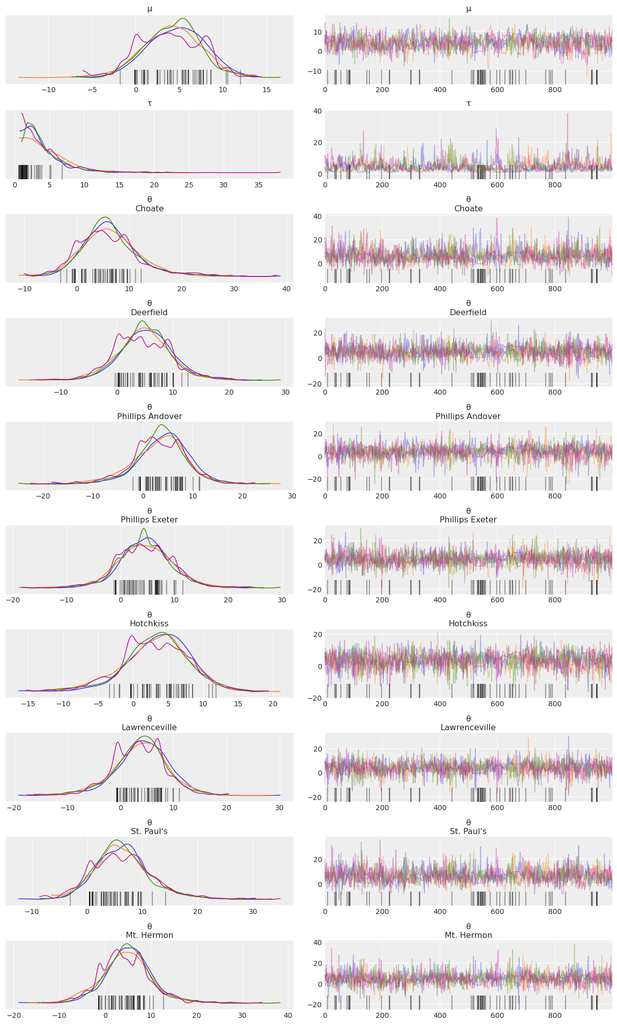

```julia
plot_trace(idata);
gcf()
```

We can also generate summary stats

```julia
summarystats(idata)
```

|  | variable String | mean Float64 | sd Float64 | hdi_3% Float64 | hdi_97% Float64 | mcse_mean Float64 | mcse_sd Float64 | ess_mean Float64 | ess_sd Float64 | ess_bulk Float64 | ess_tail Float64 | r_hat Float64 |
| --- | --- | --- | --- | --- | --- | --- | --- | --- | --- | --- | --- | --- |
| 1 | μ | 4.211 | 3.396 | -2.106 | 10.218 | 0.139 | 0.098 | 596.0 | 596.0 | 593.0 | 1223.0 | 1.01 |
| 2 | τ | 4.262 | 3.209 | 0.717 | 9.866 | 0.182 | 0.129 | 310.0 | 310.0 | 196.0 | 245.0 | 1.03 |
| 3 | θ[1] | 6.313 | 5.699 | -4.302 | 16.981 | 0.184 | 0.13 | 962.0 | 962.0 | 889.0 | 1989.0 | 1.01 |
| 4 | θ[2] | 4.897 | 4.877 | -4.709 | 13.732 | 0.142 | 0.101 | 1176.0 | 1176.0 | 1078.0 | 1818.0 | 1.01 |
| 5 | θ[3] | 3.61 | 5.496 | -7.342 | 13.434 | 0.156 | 0.11 | 1245.0 | 1245.0 | 1127.0 | 1768.0 | 1.01 |
| 6 | θ[4] | 4.585 | 5.131 | -5.398 | 13.877 | 0.135 | 0.095 | 1454.0 | 1454.0 | 1253.0 | 2147.0 | 1.01 |
| 7 | θ[5] | 3.299 | 4.774 | -6.182 | 11.952 | 0.15 | 0.106 | 1011.0 | 1011.0 | 970.0 | 1845.0 | 1.01 |
| 8 | θ[6] | 3.776 | 5.129 | -6.098 | 13.506 | 0.144 | 0.102 | 1264.0 | 1264.0 | 1174.0 | 1720.0 | 1.0 |
| 9 | θ[7] | 6.446 | 5.287 | -2.916 | 16.687 | 0.162 | 0.114 | 1069.0 | 1069.0 | 1004.0 | 1631.0 | 1.01 |
| 10 | θ[8] | 4.815 | 5.563 | -6.055 | 14.986 | 0.165 | 0.117 | 1133.0 | 1133.0 | 1034.0 | 1803.0 | 1.01 |

and examine the energy distribution of the Hamiltonian sampler

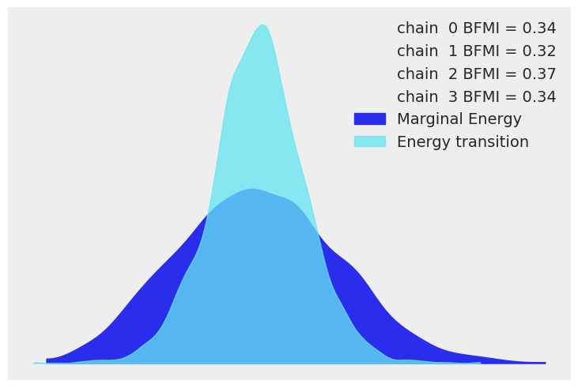

```julia
plot_energy(idata);
gcf()
```

## Plotting with CmdStan.jl outputs

CmdStan.jl and StanSample.jl also default to producing `Chains` outputs, and we can easily plot these chains.

Here is the same centered eight schools model:

```julia
using CmdStan, MCMCChains

schools_code = """
data {
  int<lower=0> J;
  real y[J];
  real<lower=0> sigma[J];
}

parameters {
  real mu;
  real<lower=0> tau;
  real theta[J];
}

model {
  mu ~ normal(0, 5);
  tau ~ cauchy(0, 5);
  theta ~ normal(mu, tau);
  y ~ normal(theta, sigma);
}

generated quantities {
    vector[J] log_lik;
    vector[J] y_hat;
    for (j in 1:J) {
        log_lik[j] = normal_lpdf(y[j] | theta[j], sigma[j]);
        y_hat[j] = normal_rng(theta[j], sigma[j]);
    }
}
"""

schools_dat = Dict("J" => J, "y" => y, "sigma" => σ)
stan_model = Stanmodel(
    model = schools_code,
    name = "schools",
    nchains = nchains,
    num_warmup = nwarmup,
    num_samples = nsamples,
    output_format = :mcmcchains,
    random = CmdStan.Random(28983),
)
_, stan_chns, _ = stan(stan_model, schools_dat, summary = false);
```

```
File /home/runner/work/ArviZ.jl/ArviZ.jl/docs/build/tmp/schools.stan will be updated.
```

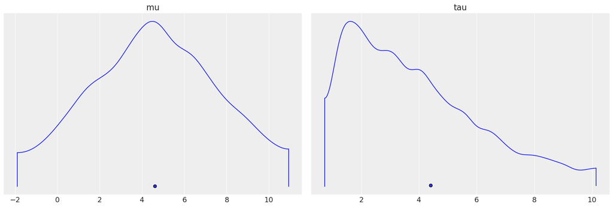

```julia
plot_density(stan_chns; var_names=["mu", "tau"]);
gcf()
```

Again, converting to `InferenceData`, we can get much richer labelling and mixing of data. Note that we're using the same `from_cmdstan` function used by ArviZ to process cmdstan output files, but through the power of dispatch in Julia, if we pass a `Chains` object, it instead uses ArviZ.jl's overloads, which forward to `from_mcmcchains`.

```julia
idata = from_cmdstan(
    stan_chns;
    posterior_predictive = "y_hat",
    observed_data = Dict("y" => schools_dat["y"]),
    log_likelihood = "log_lik",
    coords = Dict("school" => schools),
    dims = Dict(
        "y" => ["school"],
        "sigma" => ["school"],
        "theta" => ["school"],
        "log_lik" => ["school"],
        "y_hat" => ["school"],
    ),
)
```

InferenceData

- posterior

  ```
  Dataset (xarray.Dataset)
  Dimensions:  (chain: 4, draw: 1000, school: 8)
  Coordinates:
    * chain    (chain) int64 0 1 2 3
    * draw     (draw) int64 0 1 2 3 4 5 6 7 8 ... 992 993 994 995 996 997 998 999
    * school   (school) <U16 'Choate' 'Deerfield' ... "St. Paul's" 'Mt. Hermon'
  Data variables:
      theta    (chain, draw, school) float64 -0.165 0.7155 -9.24 ... 6.625 6.425
      tau      (chain, draw) float64 7.914 3.891 4.143 2.586 ... 1.266 1.731 1.655
      mu       (chain, draw) float64 0.2775 6.939 6.782 ... 5.958 5.052 5.926
  Attributes:
      created_at:         2020-10-03T09:00:31.460620
      arviz_version:      0.10.0
      inference_library:  CmdStan
  ```

- posterior_predictive

  ```
  Dataset (xarray.Dataset)
  Dimensions:  (chain: 4, draw: 1000, school: 8)
  Coordinates:
    * chain    (chain) int64 0 1 2 3
    * draw     (draw) int64 0 1 2 3 4 5 6 7 8 ... 992 993 994 995 996 997 998 999
    * school   (school) <U16 'Choate' 'Deerfield' ... "St. Paul's" 'Mt. Hermon'
  Data variables:
      y_hat    (chain, draw, school) float64 -18.59 -8.772 -9.08 ... 19.1 -13.76
  Attributes:
      created_at:         2020-10-03T09:00:31.242616
      arviz_version:      0.10.0
      inference_library:  CmdStan
  ```

- log_likelihood

  ```
  Dataset (xarray.Dataset)
  Dimensions:  (chain: 4, draw: 1000, school: 8)
  Coordinates:
    * chain    (chain) int64 0 1 2 3
    * draw     (draw) int64 0 1 2 3 4 5 6 7 8 ... 992 993 994 995 996 997 998 999
    * school   (school) <U16 'Choate' 'Deerfield' ... "St. Paul's" 'Mt. Hermon'
  Data variables:
      log_lik  (chain, draw, school) float64 -5.39 -3.487 -3.768 ... -3.869 -3.857
  Attributes:
      created_at:         2020-10-03T09:00:31.389343
      arviz_version:      0.10.0
      inference_library:  CmdStan
  ```

- sample_stats

  ```
  Dataset (xarray.Dataset)
  Dimensions:      (chain: 4, draw: 1000)
  Coordinates:
    * chain        (chain) int64 0 1 2 3
    * draw         (draw) int64 0 1 2 3 4 5 6 7 ... 993 994 995 996 997 998 999
  Data variables:
      stepsize     (chain, draw) float64 0.2197 0.2197 0.2197 ... 0.1829 0.1829
      treedepth    (chain, draw) float64 4.0 4.0 4.0 4.0 4.0 ... 4.0 3.0 3.0 3.0
      n_leapfrog   (chain, draw) float64 15.0 31.0 15.0 15.0 ... 15.0 13.0 7.0
      accept_stat  (chain, draw) float64 0.9642 0.9569 0.9648 ... 0.7453 0.9197
      diverging    (chain, draw) bool False False False ... False False False
      energy       (chain, draw) float64 27.49 25.64 21.91 ... 13.36 10.67 12.01
      lp           (chain, draw) float64 -23.04 -16.01 -15.29 ... -8.88 -9.041
  Attributes:
      created_at:         2020-10-03T09:00:31.473839
      arviz_version:      0.10.0
      inference_library:  CmdStan
  ```

- observed_data

  ```
  Dataset (xarray.Dataset)
  Dimensions:  (school: 8)
  Coordinates:
    * school   (school) <U16 'Choate' 'Deerfield' ... "St. Paul's" 'Mt. Hermon'
  Data variables:
      y        (school) float64 28.0 8.0 -3.0 7.0 -1.0 1.0 18.0 12.0
  Attributes:
      created_at:         2020-10-03T09:00:31.972990
      arviz_version:      0.10.0
      inference_library:  CmdStan
  ```

Here is a plot showing where the Hamiltonian sampler had divergences:

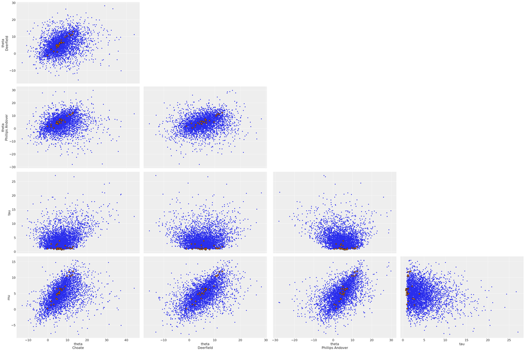

```julia
plot_pair(
    idata;
    coords = Dict("school" => ["Choate", "Deerfield", "Phillips Andover"]),
    divergences = true,
);
gcf()
```

## Plotting with Soss.jl outputs

With Soss, we can define our model for the posterior and easily use it to draw samples from the prior, prior predictive, posterior, and posterior predictive distributions.

First we define our model:

```julia
using Soss, NamedTupleTools

mod = Soss.@model (J, σ) begin
    μ ~ Normal(0, 5)
    τ ~ HalfCauchy(5)
    θ ~ Normal(μ, τ) |> iid(J)
    y ~ For(1:J) do j
        Normal(θ[j], σ[j])
    end
end

constant_data = (J = J, σ = σ)
param_mod = mod(; constant_data...)
```

```
Joint Distribution
    Bound arguments: [J, σ]
    Variables: [τ, μ, θ, y]

@model (J, σ) begin
        τ ~ HalfCauchy(5)
        μ ~ Normal(0, 5)
        θ ~ Normal(μ, τ) |> iid(J)
        y ~ For(1:J) do j
                Normal(θ[j], σ[j])
            end
    end
```

Then we draw from the prior and prior predictive distributions.

```julia
Random.seed!(5298)
prior_priorpred = [
    map(1:nchains*nsamples) do _
        draw = rand(param_mod)
        return delete(draw, keys(constant_data))
    end
];
```

Next, we draw from the posterior using DynamicHMC.jl.

```julia
post = map(1:nchains) do _
    dynamicHMC(param_mod, (y = y,), nsamples)
end;
```

Finally, we update the posterior samples with draws from the posterior predictive distribution.

```julia
pred = predictive(mod, :μ, :τ, :θ)
post_postpred = map(post) do post_draws
    map(post_draws) do post_draw
        pred_draw = rand(pred(post_draw))
        pred_draw = delete(pred_draw, keys(constant_data))
        return merge(pred_draw, post_draw)
    end
end;
```

Each Soss draw is a `NamedTuple`. We can plot the rank order statistics of the posterior to identify poor convergence:

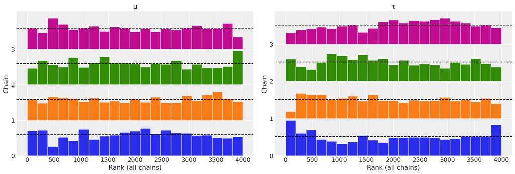

```julia
plot_rank(post; var_names = ["μ", "τ"]);
gcf()
```

Now we combine all of the samples to an `InferenceData`:

```julia
idata = from_namedtuple(
    post_postpred;
    posterior_predictive = [:y],
    prior = prior_priorpred,
    prior_predictive = [:y],
    observed_data = (y = y,),
    constant_data = constant_data,
    coords = Dict("school" => schools),
    dims = Dict(
        "y" => ["school"],
        "σ" => ["school"],
        "θ" => ["school"],
    ),
    library = Soss,
)
```

InferenceData

- posterior

  ```
  Dataset (xarray.Dataset)
  Dimensions:  (chain: 4, draw: 1000, school: 8)
  Coordinates:
    * chain    (chain) int64 0 1 2 3
    * draw     (draw) int64 0 1 2 3 4 5 6 7 8 ... 992 993 994 995 996 997 998 999
    * school   (school) <U16 'Choate' 'Deerfield' ... "St. Paul's" 'Mt. Hermon'
  Data variables:
      μ        (chain, draw) float64 6.418 3.641 5.998 ... 0.8601 -0.4761 2.658
      τ        (chain, draw) float64 0.6797 0.9006 1.077 ... 2.138 3.056 1.511
      θ        (chain, draw, school) float64 6.175 6.283 7.613 ... 2.526 0.06663
  Attributes:
      created_at:         2020-10-03T09:05:04.209568
      arviz_version:      0.10.0
      inference_library:  Soss
  ```

- posterior_predictive

  ```
  Dataset (xarray.Dataset)
  Dimensions:  (chain: 4, draw: 1000, school: 8)
  Coordinates:
    * chain    (chain) int64 0 1 2 3
    * draw     (draw) int64 0 1 2 3 4 5 6 7 8 ... 992 993 994 995 996 997 998 999
    * school   (school) <U16 'Choate' 'Deerfield' ... "St. Paul's" 'Mt. Hermon'
  Data variables:
      y        (chain, draw, school) float64 -15.0 -10.52 -4.4 ... 9.305 -28.85
  Attributes:
      created_at:         2020-10-03T09:05:04.164794
      arviz_version:      0.10.0
      inference_library:  Soss
  ```

- prior

  ```
  Dataset (xarray.Dataset)
  Dimensions:  (chain: 1, draw: 4000, school: 8)
  Coordinates:
    * chain    (chain) int64 0
    * draw     (draw) int64 0 1 2 3 4 5 6 7 ... 3993 3994 3995 3996 3997 3998 3999
    * school   (school) <U16 'Choate' 'Deerfield' ... "St. Paul's" 'Mt. Hermon'
  Data variables:
      μ        (chain, draw) float64 -1.058 6.136 -0.3852 ... 1.484 -10.82 -0.7505
      τ        (chain, draw) float64 149.7 0.02342 3.398 ... 4.347 84.28 4.543
      θ        (chain, draw, school) float64 -8.511 154.9 44.86 ... -2.911 -6.732
  Attributes:
      created_at:         2020-10-03T09:05:05.520344
      arviz_version:      0.10.0
      inference_library:  Soss
  ```

- prior_predictive

  ```
  Dataset (xarray.Dataset)
  Dimensions:  (chain: 1, draw: 4000, school: 8)
  Coordinates:
    * chain    (chain) int64 0
    * draw     (draw) int64 0 1 2 3 4 5 6 7 ... 3993 3994 3995 3996 3997 3998 3999
    * school   (school) <U16 'Choate' 'Deerfield' ... "St. Paul's" 'Mt. Hermon'
  Data variables:
      y        (chain, draw, school) float64 -19.44 137.9 18.57 ... 5.947 13.3
  Attributes:
      created_at:         2020-10-03T09:05:05.517917
      arviz_version:      0.10.0
      inference_library:  Soss
  ```

- observed_data

  ```
  Dataset (xarray.Dataset)
  Dimensions:  (school: 8, y_dim_0: 8)
  Coordinates:
    * y_dim_0  (y_dim_0) int64 0 1 2 3 4 5 6 7
    * school   (school) <U16 'Choate' 'Deerfield' ... "St. Paul's" 'Mt. Hermon'
  Data variables:
      y        (y_dim_0) float64 28.0 8.0 -3.0 7.0 -1.0 1.0 18.0 12.0
  Attributes:
      created_at:         2020-10-03T09:05:06.697896
      arviz_version:      0.10.0
      inference_library:  Soss
  ```

- constant_data

  ```
  Dataset (xarray.Dataset)
  Dimensions:  (J_dim_0: 1, school: 8, σ_dim_0: 8)
  Coordinates:
    * J_dim_0  (J_dim_0) int64 0
    * σ_dim_0  (σ_dim_0) int64 0 1 2 3 4 5 6 7
    * school   (school) <U16 'Choate' 'Deerfield' ... "St. Paul's" 'Mt. Hermon'
  Data variables:
      J        (J_dim_0) int64 8
      σ        (σ_dim_0) float64 15.0 10.0 16.0 11.0 9.0 11.0 10.0 18.0
  Attributes:
      created_at:         2020-10-03T09:05:07.460211
      arviz_version:      0.10.0
      inference_library:  Soss
  ```

We can compare the prior and posterior predictive distributions:

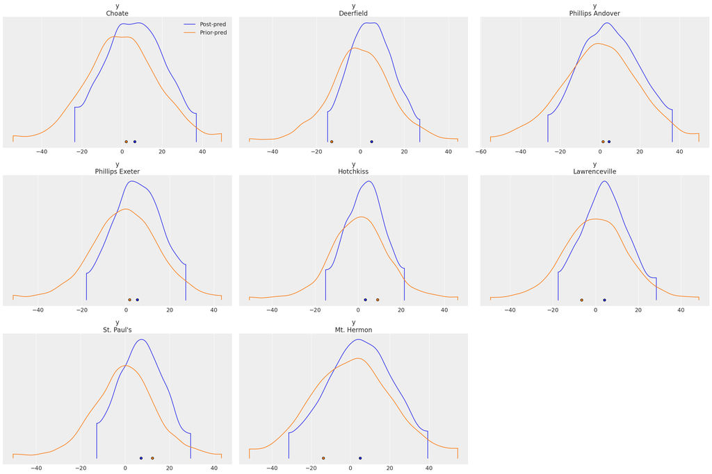

```julia
plot_density(
    [idata.posterior_predictive, idata.prior_predictive];
    data_labels = ["Post-pred", "Prior-pred"],
    var_names = ["y"],
)
gcf()
```

## Environment

```julia
using Pkg
Pkg.status()
```

```
Status `~/work/ArviZ.jl/ArviZ.jl/docs/Project.toml`
  [131c737c] ArviZ v0.4.5 `~/work/ArviZ.jl/ArviZ.jl`
  [593b3428] CmdStan v6.0.9
  [31c24e10] Distributions v0.23.8
  [e30172f5] Documenter v0.25.2
  [c7f686f2] MCMCChains v4.2.2
  [d9ec5142] NamedTupleTools v0.13.6
  [438e738f] PyCall v1.92.1
  [d330b81b] PyPlot v2.9.0
  [8ce77f84] Soss v0.14.4
  [fce5fe82] Turing v0.14.6
```

```julia
using InteractiveUtils
versioninfo()
```

```
Julia Version 1.5.2
Commit 539f3ce943 (2020-09-23 23:17 UTC)
Platform Info:
  OS: Linux (x86_64-pc-linux-gnu)
  CPU: Intel(R) Xeon(R) CPU E5-2673 v4 @ 2.30GHz
  WORD_SIZE: 64
  LIBM: libopenlibm
  LLVM: libLLVM-9.0.1 (ORCJIT, broadwell)
Environment:
  JULIA_CMDSTAN_HOME = /home/runner/work/ArviZ.jl/ArviZ.jl/.cmdstan//cmdstan-2.23.0/
  JULIA_NUM_THREADS = 2
```